# Aids Drug

Sammy

May 22, 2020

# Introduction

A new preventative aides (triUmpsal) is under test in clinical trials. Analyze the effectiveness of this drug across the board. Consider population subgroups by gender, drug use, and sexual orientation. Finish this!

# Methods

Since each question is categorical-categorical we use the same methods in each.

Graphical summary: bar chart Numeric summary: cross tabulation, table form. Inference: Chi-squared test, and Fishers exact test.

does the vacine effect whether one contracts aids or not in the general population?

$H_0$: The vacine has no effect that one contracts aids or not.

$H_A$: The vacine does have an effect.

# Results

## Descriptive Results

### Graphical Descriptive Results

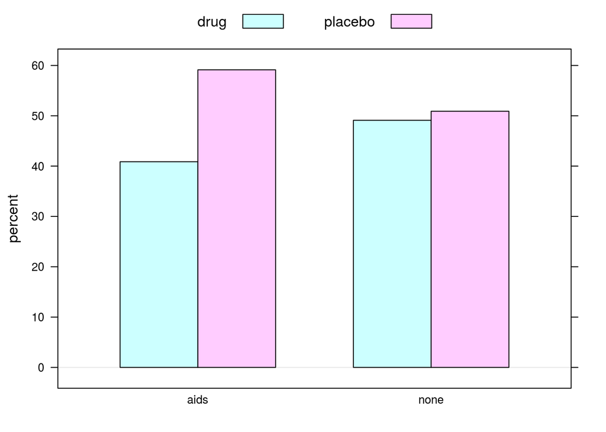

```r
barchartGC(~infected + treatment,data=triUmp,type = "percent" )
```

The bar charts shows among those who got aids looks like fewer contracted aids if they had the vacine.

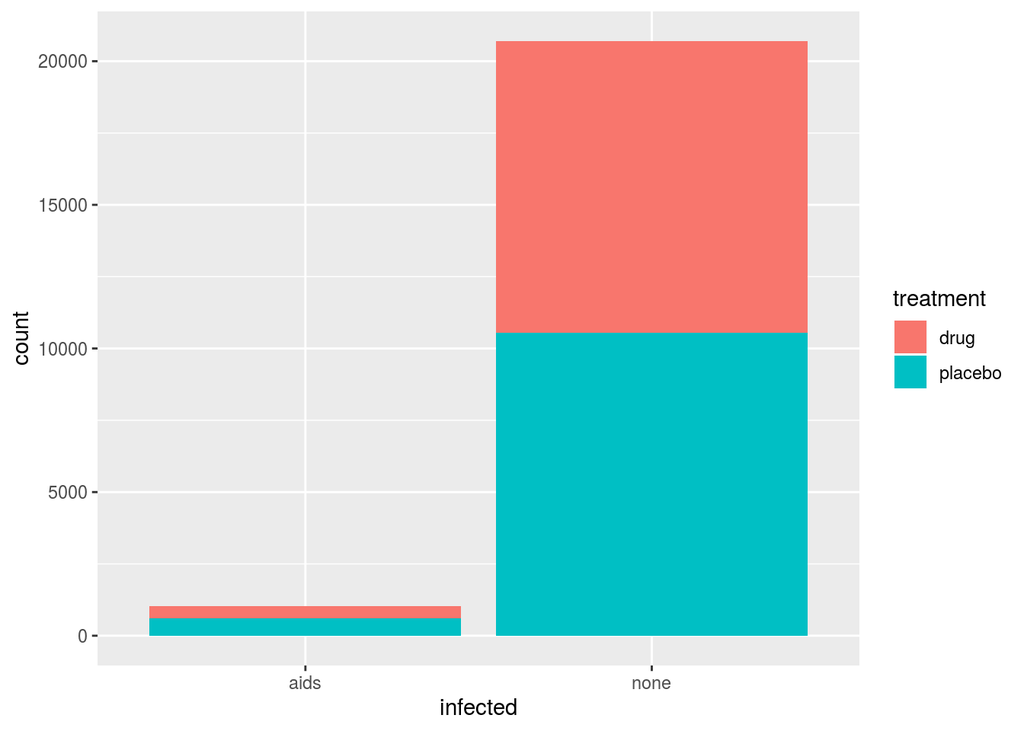

```r
basicCC <- ggplot(triUmp,aes(x=infected,fill=treatment))
basicCC + geom_bar()
```

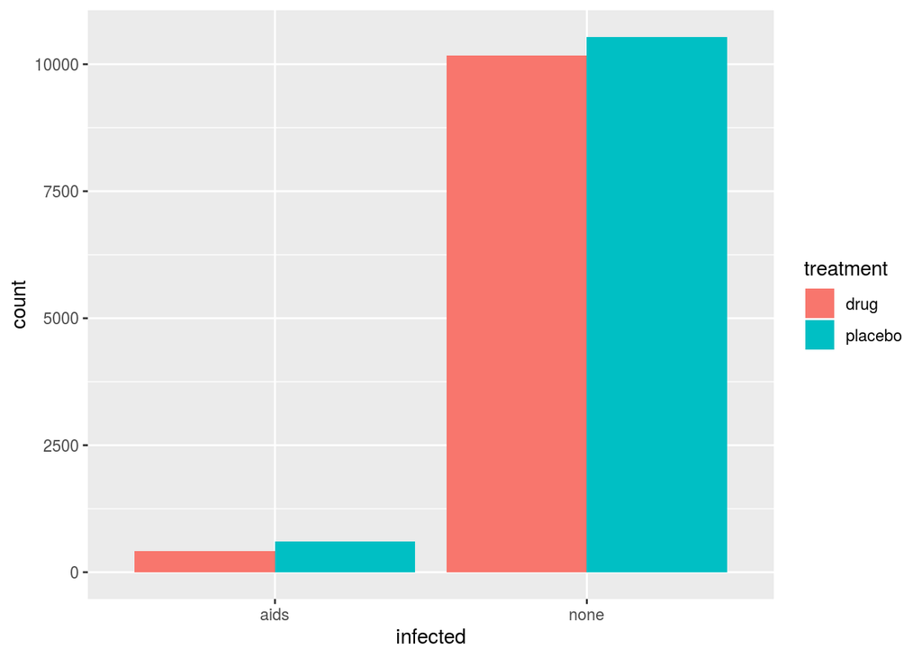

```r
basicCC + geom_bar(position=position_dodge())
```

### Numerical Descriptive Results

```r
table1 <- xtabs(~infected + treatment,data=triUmp)
rowPerc(table1)
```

```
##         treatment
## infected   drug placebo  Total
##     aids  40.87   59.13 100.00
##     none  49.10   50.90 100.00
```

```r
colPerc(table1)
```

```
##         treatment
## infected   drug placebo
##    aids    3.99    5.49
##    none   96.01   94.51
##    Total 100.00  100.00
```

these tables show the numerical results by percentage…

## Inferential Results

```r
chisq.test(table1)
```

```
##
##  Pearson's Chi-squared test with Yates' continuity correction
##
## data:  table1
## X-squared = 26.41, df = 1, p-value = 2.761e-07
```

```r
chisqtestGC(table1)
```

```
## Pearson's Chi-squared test with Yates' continuity correction
##
## Observed Counts:
##         treatment
## infected  drug placebo
##     aids   423     612
##     none 10168   10540
##
## Counts Expected by Null:
##         treatment
## infected     drug  placebo
##     aids   504.15   530.85
##     none 10086.85 10621.15
##
## Contributions to the chi-square statistic:
##         treatment
## infected  drug placebo
##     aids 13.06   12.40
##     none  0.65    0.62
##
##
## Chi-Square Statistic = 26.4104
## Degrees of Freedom of the table = 1
## P-Value = 0
```

```r
fisher.test(table1)
```

```
##
##  Fisher's Exact Test for Count Data
##
## data:  table1
## p-value = 2.333e-07
## alternative hypothesis: true odds ratio is not equal to 1
## 95 percent confidence interval:
##  0.6295438 0.8148378
## sample estimates:
## odds ratio
##  0.7164774
```

# question2

does the vacine effect whether one contracts aids or not among females.

$H_0$: The vacine has no effect that one contracts aids or not.

$H_A$: The vacine does have an effect.

# Results

## Descriptive Results

### Graphical Descriptive Results

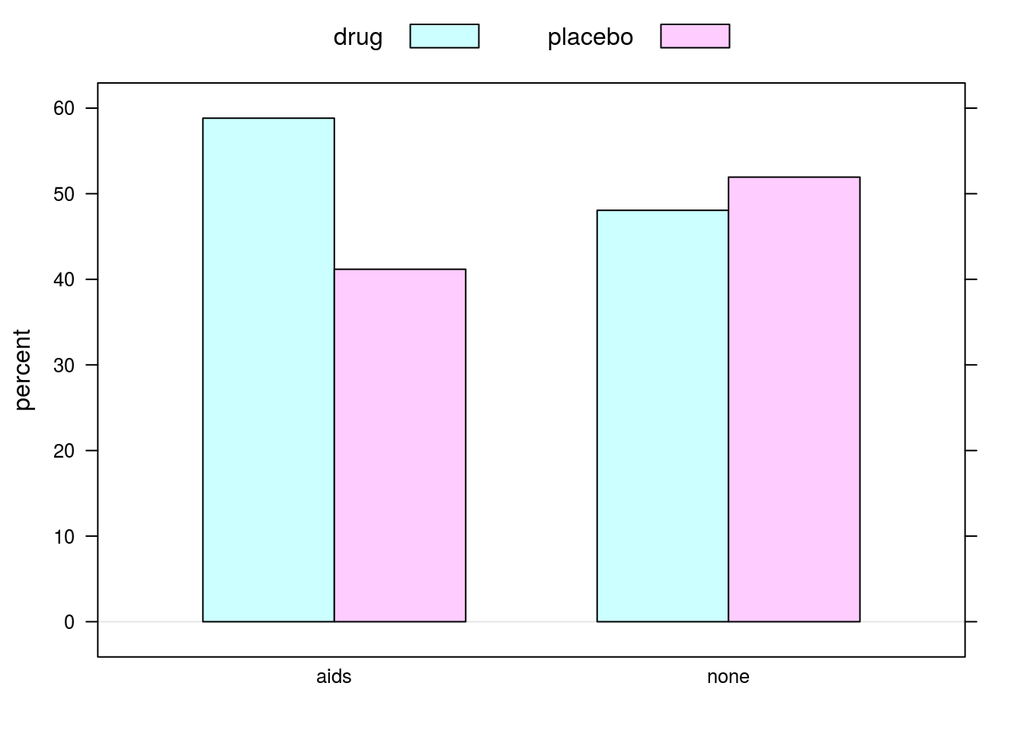

```r
females <- filter(triUmp,gender =="F")
barchartGC(~infected + treatment,data=females,type = "percent" )
```

The bar charts shows that it did have an affect on weather female aquired aids. The affect show that it worked backwards. They received aids more.

The bar chart shows tht vacine did effect wheater a female contacted aids by making them more susceptible.

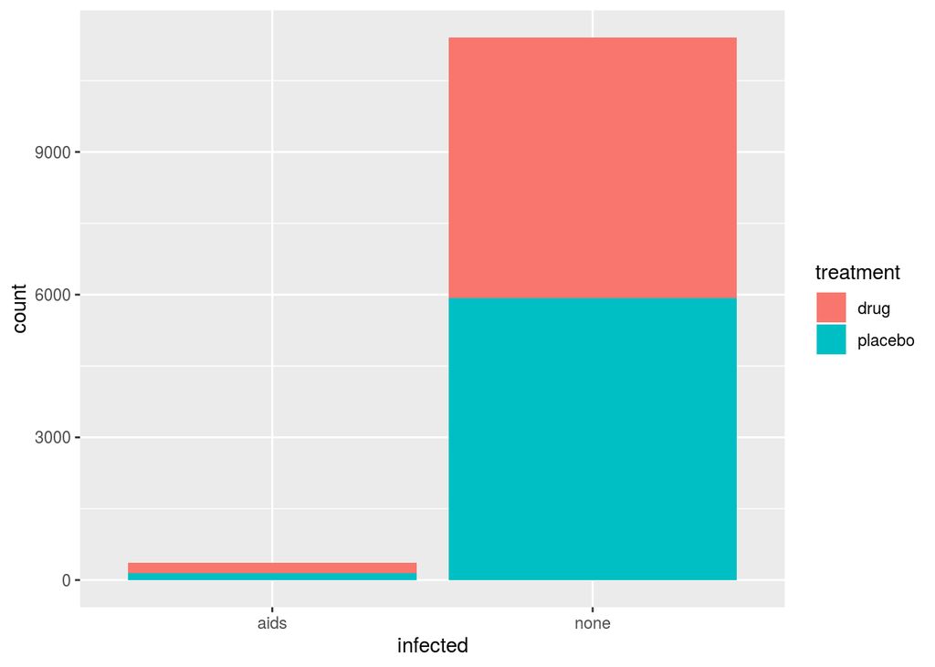

```r
basicCC <- ggplot(females,aes(x=infected,fill=treatment))
basicCC + geom_bar()
```

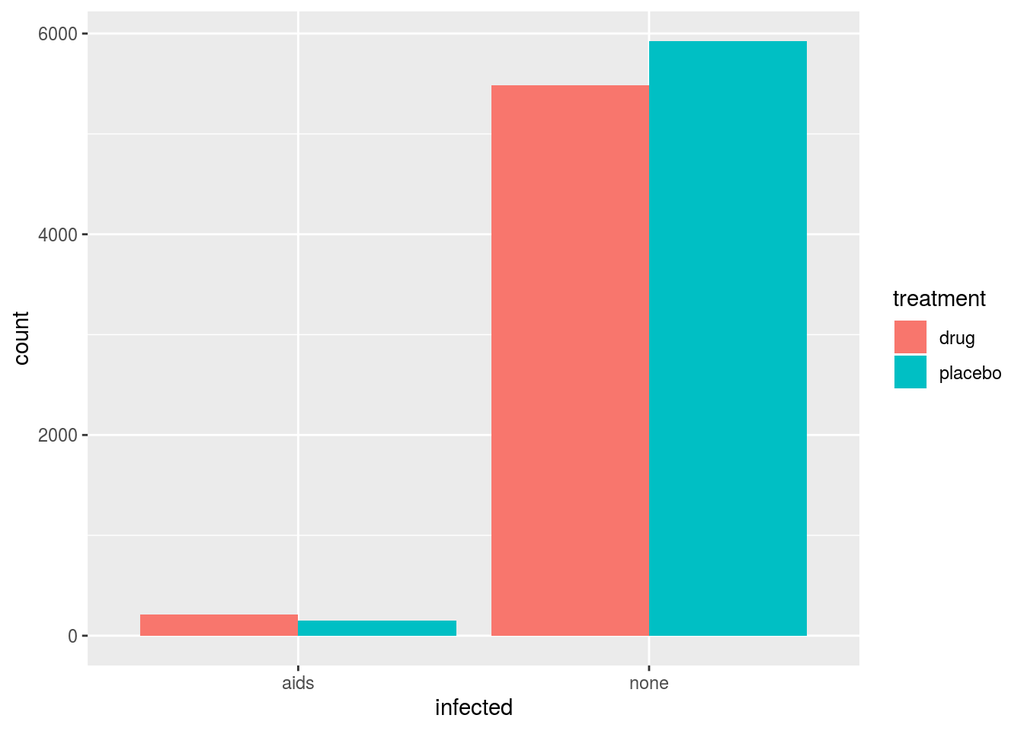

```r
basicCC + geom_bar(position=position_dodge())
```

### Numerical Descriptive Results

```r
table2 <- xtabs(~infected + treatment,data=females)
rowPerc(table2)
```

```
##         treatment
## infected   drug placebo  Total
##     aids  58.82   41.18 100.00
##     none  48.06   51.94 100.00
```

```r
colPerc(table2)
```

```
##         treatment
## infected   drug placebo
##    aids    3.69    2.42
##    none   96.31   97.58
##    Total 100.00  100.00
```

## Inferential Results

```r
chisq.test(table2)
```

```
##
##  Pearson's Chi-squared test with Yates' continuity correction
##
## data:  table2
## X-squared = 15.634, df = 1, p-value = 7.686e-05
```

```r
chisqtestGC(table2)
```

```
## Pearson's Chi-squared test with Yates' continuity correction
##
## Observed Counts:
##         treatment
## infected drug placebo
##     aids  210     147
##     none 5484    5927
##
## Counts Expected by Null:
##         treatment
## infected    drug placebo
##     aids  172.74  184.26
##     none 5521.26 5889.74
##
## Contributions to the chi-square statistic:
##         treatment
## infected drug placebo
##     aids 8.04    7.54
##     none 0.25    0.24
##
##
## Chi-Square Statistic = 15.6339
## Degrees of Freedom of the table = 1
## P-Value = 1e-04
```

```r
fisher.test(table2)
```

```
##
##  Fisher's Exact Test for Count Data
##
## data:  table2
## p-value = 6.596e-05
## alternative hypothesis: true odds ratio is not equal to 1
## 95 percent confidence interval:
##  1.240408 1.925729
## sample estimates:
## odds ratio
##   1.543902
```

according to the fisher exact test the odds are 1.5 in females taking the drug and contracting aids. Therefore the females have 1.5 chance of getting aids over those that take the placebo.

# Discussion and Conclusion

Pvalue is less than .05, therefore we reject the NH. The vacine worked backwards so female population should avoid the vacine.

# question3

does the vacine effect whether one contracts aids or not among males.

$H_0$: The vacine has no effect that one contracts aids or not.

$H_A$: The vacine does have an effect.

# Results

## Descriptive Results

### Graphical Descriptive Results

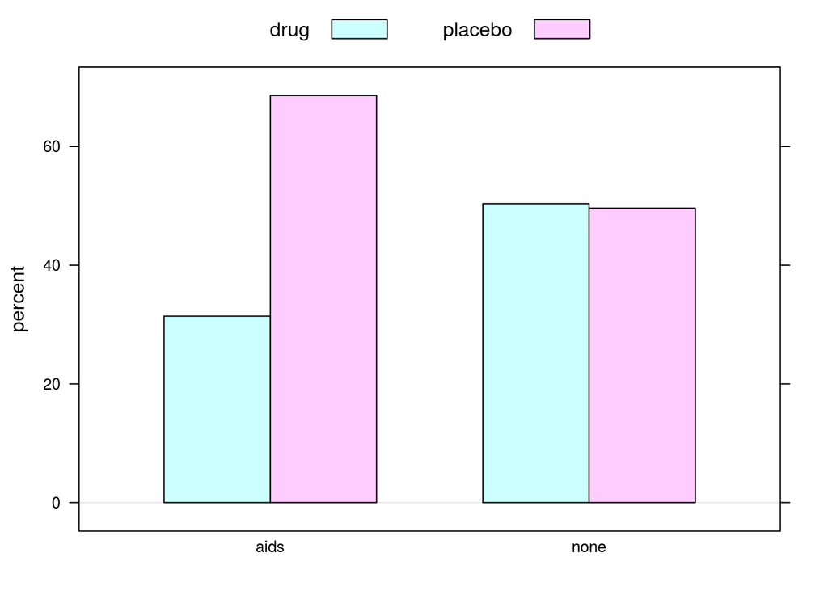

```r
males <- filter(triUmp,gender =="M")
barchartGC(~infected + treatment,data=males,type = "percent" )
```

The bar charts shows that it did have an affect on whether male aquired aids.

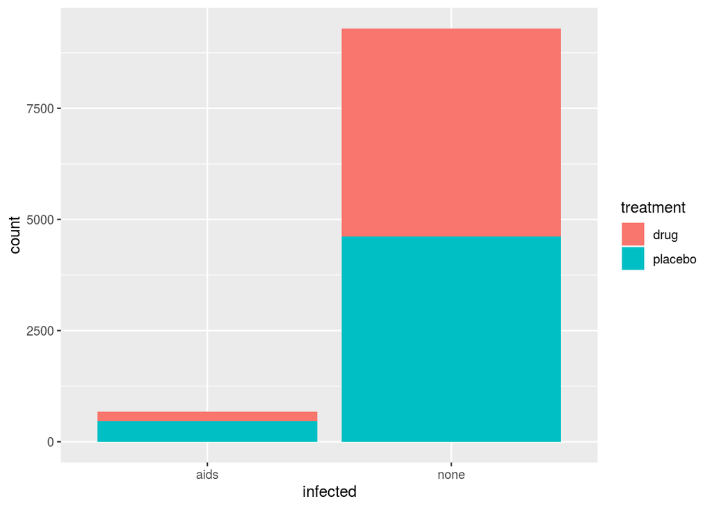

```r
basicCC <- ggplot(males,aes(x=infected,fill=treatment))
basicCC + geom_bar()
```

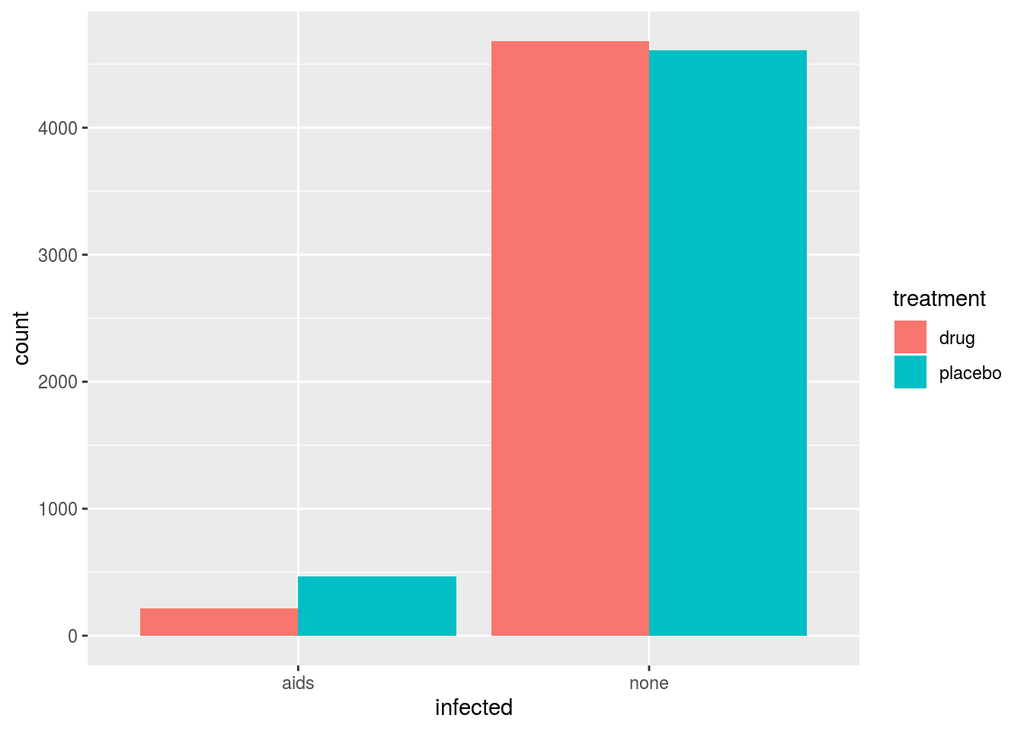

```r
basicCC + geom_bar(position=position_dodge())
```

### Numerical Descriptive Results

```r
table3 <- xtabs(~infected + treatment,data=males)
rowPerc(table3)
```

```
##         treatment
## infected   drug placebo  Total
##     aids  31.42   68.58 100.00
##     none  50.38   49.62 100.00
```

```r
colPerc(table3)
```

```
##         treatment
## infected   drug placebo
##    aids    4.35    9.16
##    none   95.65   90.84
##    Total 100.00  100.00
```

## Inferential Results

```r
chisq.test(table3)
```

```
##
##  Pearson's Chi-squared test with Yates' continuity correction
##
## data:  table3
## X-squared = 90.194, df = 1, p-value < 2.2e-16
```

```r
chisqtestGC(table3)
```

```
## Pearson's Chi-squared test with Yates' continuity correction
##
## Observed Counts:
##         treatment
## infected drug placebo
##     aids  213     465
##     none 4684    4613
##
## Counts Expected by Null:
##         treatment
## infected    drug placebo
##     aids  332.85  345.15
##     none 4564.15 4732.85
##
## Contributions to the chi-square statistic:
##         treatment
## infected  drug placebo
##     aids 43.15   41.62
##     none  3.15    3.03
##
##
## Chi-Square Statistic = 90.1943
## Degrees of Freedom of the table = 1
## P-Value = 0
```

```r
fisher.test(table3)
```

```
##
##  Fisher's Exact Test for Count Data
##
## data:  table3
## p-value < 2.2e-16
## alternative hypothesis: true odds ratio is not equal to 1
## 95 percent confidence interval:
##  0.3798342 0.5345407
## sample estimates:
## odds ratio
##  0.4511536
```

# Discussion and Conclusion

Pvalue is less than .05, so I reject the NH. We have evidence the it works on the male population.

# question4

does the vacine effect whether one contracts aids or not among drug users.

$H_0$: The vacine has no effect that one contracts aids or not.

$H_A$: The vacine does have an effect.

# Results

## Descriptive Results

### Graphical Descriptive Results

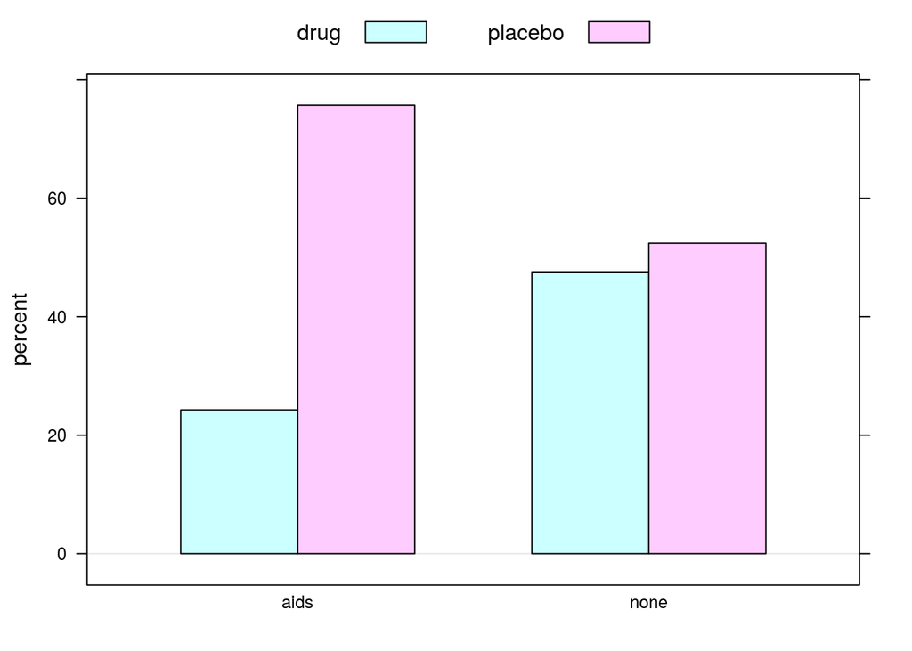

```r
CrackHead <- filter(triUmp,DrugUser =="yes")
barchartGC(~infected + treatment,data=CrackHead,type = "percent" )
```

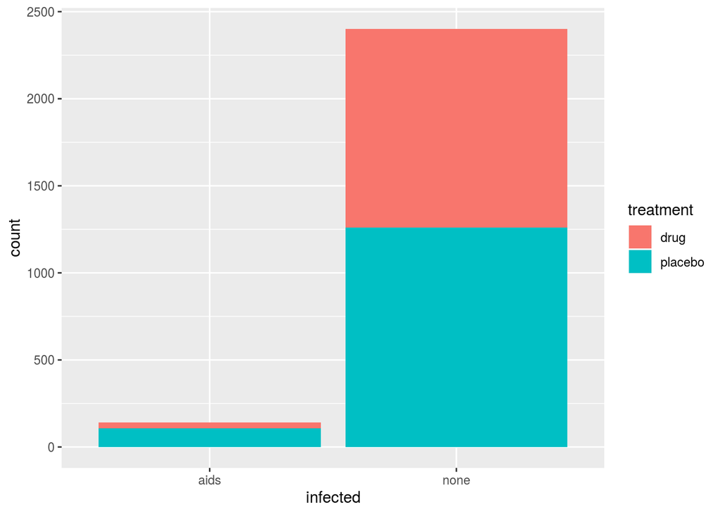

```r
basicCC <- ggplot(CrackHead,aes(x=infected,fill=treatment))
basicCC + geom_bar()
```

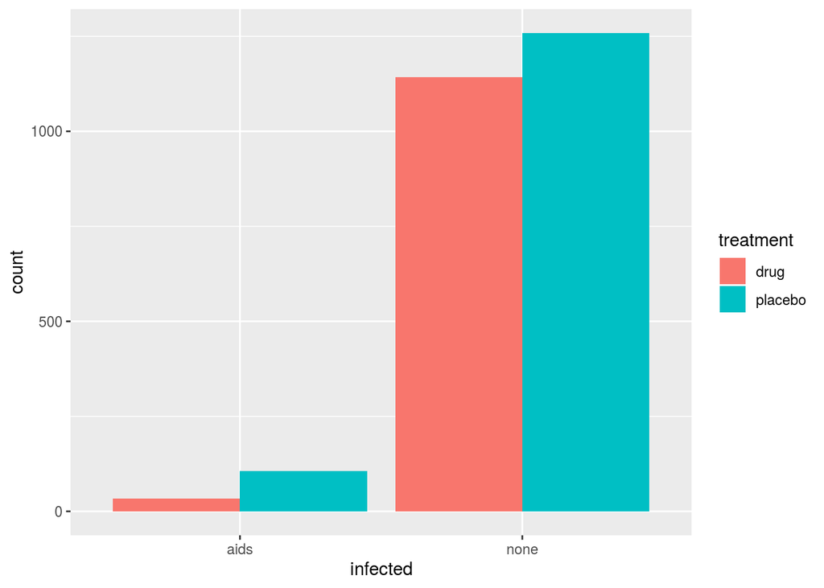

```r
basicCC + geom_bar(position=position_dodge())
```

### Numerical Descriptive Results

```r
table4 <- xtabs(~infected + treatment,data=CrackHead)
rowPerc(table4)
```

```
##         treatment
## infected   drug placebo  Total
##     aids  24.29   75.71 100.00
##     none  47.59   52.41 100.00
```

```r
colPerc(table4)
```

```
##         treatment
## infected   drug placebo
##    aids    2.89    7.77
##    none   97.11   92.23
##    Total 100.00  100.00
```

## Inferential Results

```r
chisq.test(table4)
```

```
##
##  Pearson's Chi-squared test with Yates' continuity correction
##
## data:  table4
## X-squared = 27.955, df = 1, p-value = 1.242e-07
```

```r
chisqtestGC(table4)
```

```
## Pearson's Chi-squared test with Yates' continuity correction
##
## Observed Counts:
##         treatment
## infected drug placebo
##     aids   34     106
##     none 1143    1259
##
## Counts Expected by Null:
##         treatment
## infected    drug placebo
##     aids   64.82   75.18
##     none 1112.18 1289.82
##
## Contributions to the chi-square statistic:
##         treatment
## infected  drug placebo
##     aids 14.66   12.64
##     none  0.85    0.74
##
##
## Chi-Square Statistic = 27.955
## Degrees of Freedom of the table = 1
## P-Value = 0
```

```r
fisher.test(table4)
```

```
##
##  Fisher's Exact Test for Count Data
##
## data:  table4
## p-value = 4.23e-08
## alternative hypothesis: true odds ratio is not equal to 1
## 95 percent confidence interval:
##  0.2308342 0.5294225
## sample estimates:
## odds ratio
##  0.3534128
```

# Discussion and Conclusion

Pvalue is less than .05, so I reject the NH. We have evidence the it works on the DrugUser population.

# question5

does the vacine effect whether one contracts aids or not among LBGTQ.

$H_0$: The vacine has no effect that one contracts aids or not.

$H_A$: The vacine does have an effect.

# Results

## Descriptive Results

### Graphical Descriptive Results

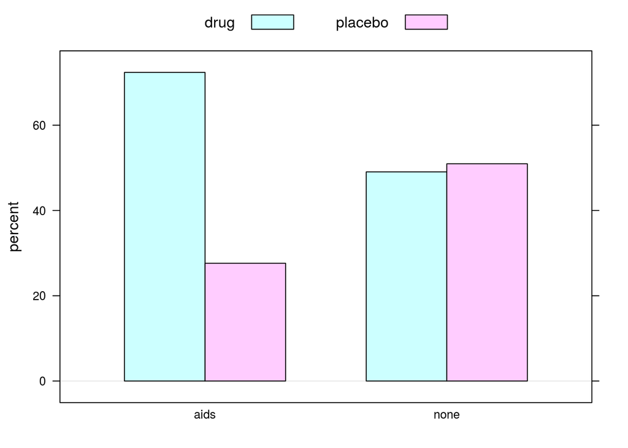

```r
lbgtqdata <- filter(triUmp, LGBTQ !="straight")
barchartGC(~infected + treatment,data=lbgtqdata,type = "percent" )
```

The bar charts shows that it did have an affect on weather lbgtqdata aquired aids. The affect show that it worked backwards. They received aids more.

The bar chart shows tht vacine did effect wheater a lbgtqdata contacted aids by making them more susceptible.

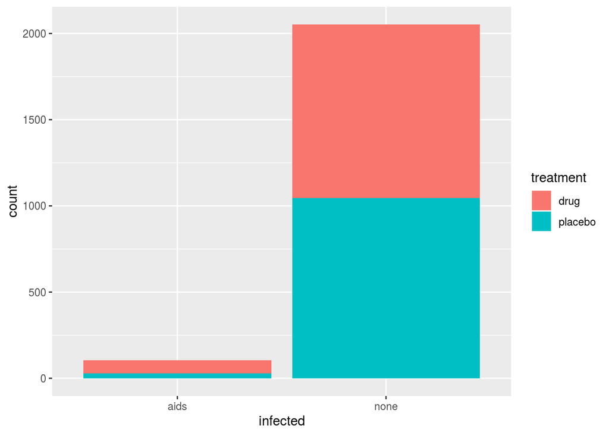

```r
basicCC <- ggplot(lbgtqdata,aes(x=infected,fill=treatment))
basicCC + geom_bar()
```

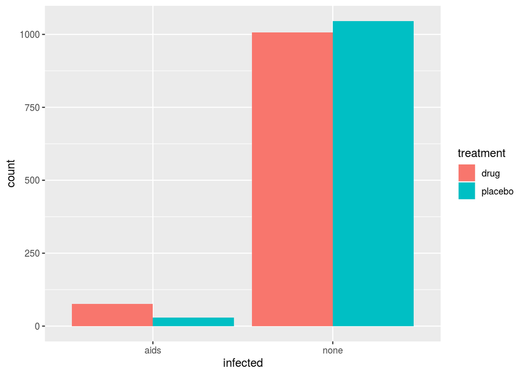

```r
basicCC + geom_bar(position=position_dodge())
```

### Numerical Descriptive Results

```r
table5 <- xtabs(~infected + treatment,data=lbgtqdata)
rowPerc(table5)
```

```
##         treatment
## infected   drug placebo  Total
##     aids  72.38   27.62 100.00
##     none  49.05   50.95 100.00
```

```r
colPerc(table5)
```

```
##         treatment
## infected   drug placebo
##    aids    7.02     2.7
##    none   92.98    97.3
##    Total 100.00   100.0
```

## Inferential Results

```r
chisq.test(table5)
```

```
##
##  Pearson's Chi-squared test with Yates' continuity correction
##
## data:  table5
## X-squared = 20.826, df = 1, p-value = 5.029e-06
```

```r
chisqtestGC(table5)
```

```
## Pearson's Chi-squared test with Yates' continuity correction
##
## Observed Counts:
##         treatment
## infected drug placebo
##     aids   76      29
##     none 1007    1046
##
## Counts Expected by Null:
##         treatment
## infected    drug placebo
##     aids   52.69   52.31
##     none 1030.31 1022.69
##
## Contributions to the chi-square statistic:
##         treatment
## infected  drug placebo
##     aids 10.31   10.38
##     none  0.53    0.53
##
##
## Chi-Square Statistic = 20.8264
## Degrees of Freedom of the table = 1
## P-Value = 0
```

```r
fisher.test(table5)
```

```
##
##  Fisher's Exact Test for Count Data
##
## data:  table5
## p-value = 2.998e-06
## alternative hypothesis: true odds ratio is not equal to 1
## 95 percent confidence interval:
##  1.735490 4.369508
## sample estimates:
## odds ratio
##   2.720997
```

according to the fisher exact test the odds are 2.7 in LGBTQ taking the drug and contracting aids. Therefore the LGBTQ have 2.7 chance of getting aids over those that take the placebo.

# Discussion and Conclusion

Pvalue is less than .05, therefore we reject the NH. The vacine worked backwards so lbgtq population should avoid the vacine.